# Sessão 5.2: Tipos de Gráficos Essenciais com ggplot2

Norbreto Jorge Gonçalves

6 de Julho de 2025

# 1. Tipos de Gráficos Essenciais com ggplot2

Nesta sessão, vamos explorar os tipos de gráficos mais comuns e úteis para a análise exploratória de dados, usando o ggplot2.

```r
library(ggplot2)
# Usaremos o dataset mtcars e iris
data(mtcars)
data(iris)
```

1.1. Gráficos de Barras (geom_bar() ou geom_col()) Os gráficos de barras são usados para visualizar a distribuição de variáveis categóricas. • geom_bar(): Conta o número de observações em cada categoria (frequência). • geom_col(): Requer uma coluna com os valores já contados (e.g., média, soma). Exemplo 1: Frequência de Cilindros (cyl) no mtcars A variável cyl é numérica, mas pode ser tratada como categórica para este gráfico.

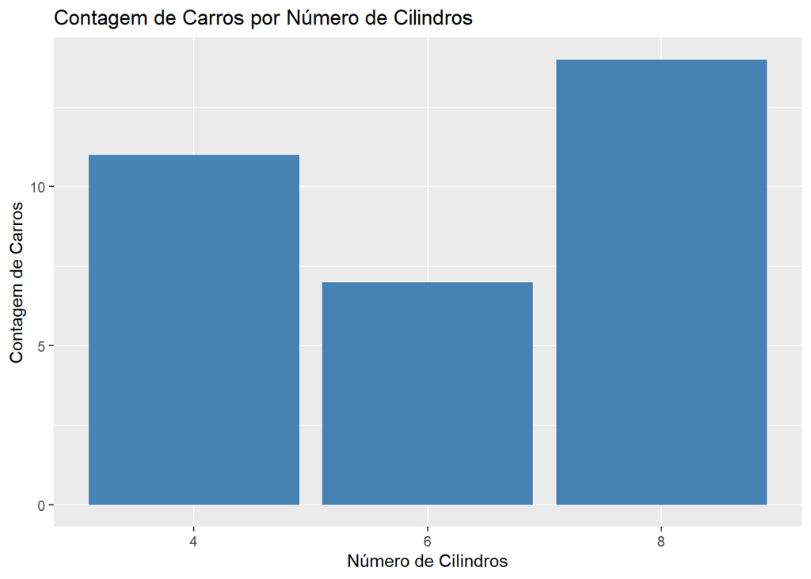

```r
# Converter 'cyl' para fator para que o ggplot2 a trate como categórica
mtcars$cyl_factor <- as.factor(mtcars$cyl)

ggplot(data = mtcars, aes(x = cyl_factor)) +
  geom_bar(fill = "steelblue") + # Preenche as barras com azul
  labs(
    title = "Contagem de Carros por Número de Cilindros",
    x = "Número de Cilindros",
    y = "Contagem de Carros"
  )
```

Exemplo 2: Média de mpg por cyl (usando geom_col()) Para mostrar uma estatística (como a média) por categoria, é melhor pré-calcular com dplyr e usar geom_col().

```r
library(dplyr) # Para usar group_by e summarise
```

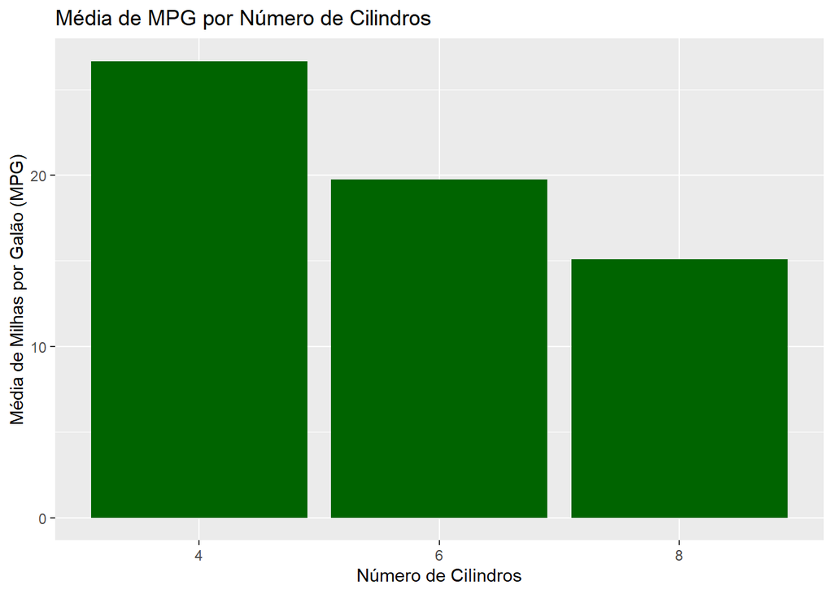

```r
# Calcular a média de mpg por número de cilindros
media_mpg_por_cyl <- mtcars %>%
  group_by(cyl_factor) %>%
  summarise(Media_MPG = mean(mpg))

ggplot(data = media_mpg_por_cyl, aes(x = cyl_factor, y = Media_MPG)) +
  geom_col(fill = "darkgreen") +
  labs(
    title = "Média de MPG por Número de Cilindros",
    x = "Número de Cilindros",
    y = "Média de Milhas por Galão (MPG)"
  )
```

# 1.2. Histogramas (geom_histogram())

Histogramas são usados para visualizar a distribuição de variáveis numéricas. Eles dividem os dados em “caixas” (bins) e contam quantas observações caem em cada caixa. Exemplo: Distribuição de Sepal.Length no iris

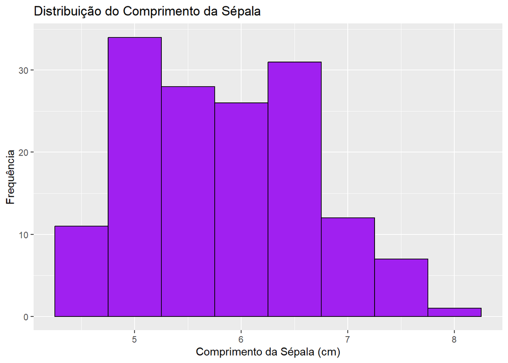

```r
ggplot(data = iris, aes(x = Sepal.Length)) +
  geom_histogram(binwidth = 0.5, fill = "purple", color = "black") + # binwidth define a largura das caixas
  labs(
    title = "Distribuição do Comprimento da Sépala",
    x = "Comprimento da Sépala (cm)",
    y = "Frequência"
  )
```

Histograma com cores por categoria

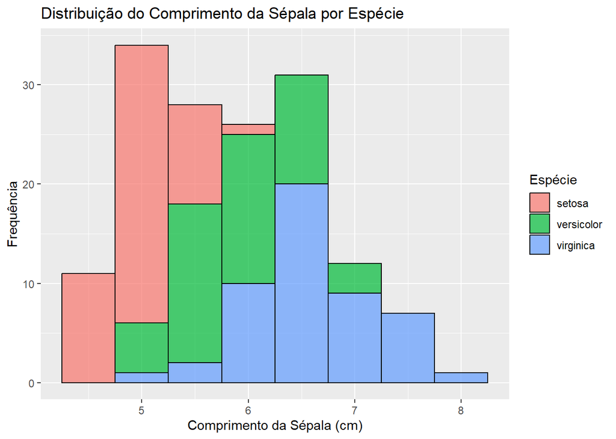

```r
ggplot(data = iris, aes(x = Sepal.Length, fill = Species)) +
  geom_histogram(binwidth = 0.5, color = "black", alpha = 0.7) + # alpha para transparência
  labs(
    title = "Distribuição do Comprimento da Sépala por Espécie",
    x = "Comprimento da Sépala (cm)",
    y = "Frequência",
    fill = "Espécie"
  )
```

## 1.3. Gráficos de Dispersão (Scatter Plots) (geom_point()) Gráficos de dispersão são usados para visualizar a relação entre duas variáveis numéricas. Exemplo: hp vs mpg no mtcars

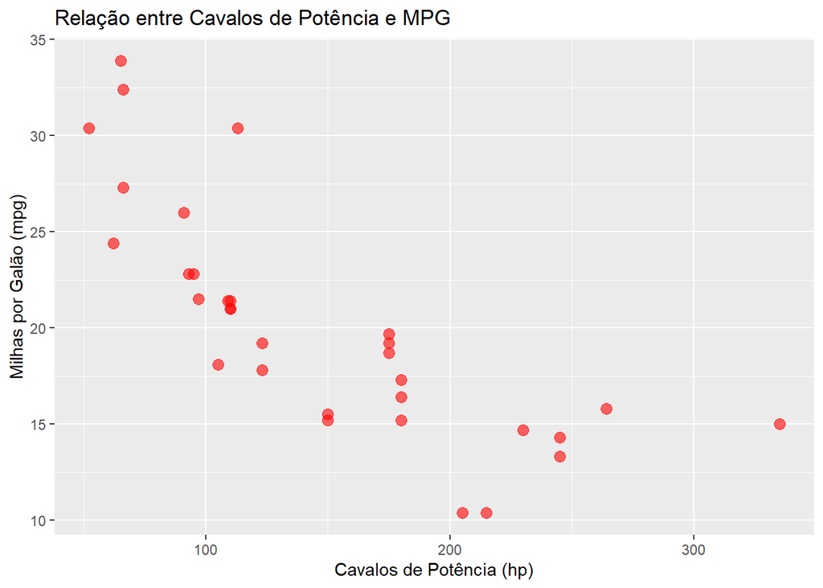

```r
ggplot(data = mtcars, aes(x = hp, y = mpg)) +
  geom_point(color = "red", size = 3, alpha = 0.6) +
  labs(
    title = "Relação entre Cavalos de Potência e MPG",
    x = "Cavalos de Potência (hp)",
    y = "Milhas por Galão (mpg)"
  )
```

Gráfico de Dispersão com cores e formas por categoria Podemos mapear variáveis categóricas para cor, tamanho ou forma dos pontos para adicionar mais dimensões à visualização.

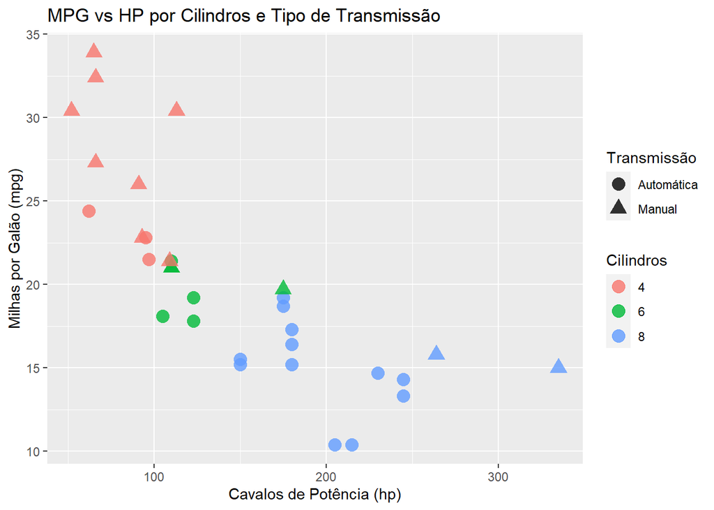

```r
# Converter 'am' (transmissão) para fator
mtcars$am_factor <- as.factor(mtcars$am)
levels(mtcars$am_factor) <- c("Automática", "Manual") # Renomear níveis

ggplot(data = mtcars, aes(x = hp, y = mpg, color = cyl_factor, shape = am_factor)) +
  geom_point(size = 4, alpha = 0.8) +
  labs(
    title = "MPG vs HP por Cilindros e Tipo de Transmissão",
    x = "Cavalos de Potência (hp)",
    y = "Milhas por Galão (mpg)",
    color = "Cilindros",
    shape = "Transmissão"
  )
```

________________________________________ **Parabéns!** Já sabem como criar os gráficos essenciais para a exploração de dados!